# Advanced graphing

ggplot

2022-10-02

> Data visualization is an accessible, compelling, and expressive mode to investigate and depict patterns in data [1].

Here is a reminder of variable types and plot types.

| y | x | plot | Base R | ggplot |
| --- | --- | --- | --- | --- |
|  | numeric | histogram, density | hist, stripchart | geom_histogram, geom_density |
|  | categorical | (stacked) bar | barchart | geom_bar |
| numeric | numeric | scatter | plot | geom_point |
| numeric | categorical | box | boxplot | geom_boxplot |

## ggplot

[Get Started](https://ggplot2-book.org/getting-started.html)

Every ggplot2 plot has three key components:

1. data,
2. A set of aesthetic mappings between variables in the data and visual properties, and
3. At least one layer which describes how to render each observation. Layers are usually created with a geom function.

```r
library(ggplot2)
```

## Scatter Plots

Use for bivariate numeric data (i.e., both $x$ and $y$ are numeric variables).

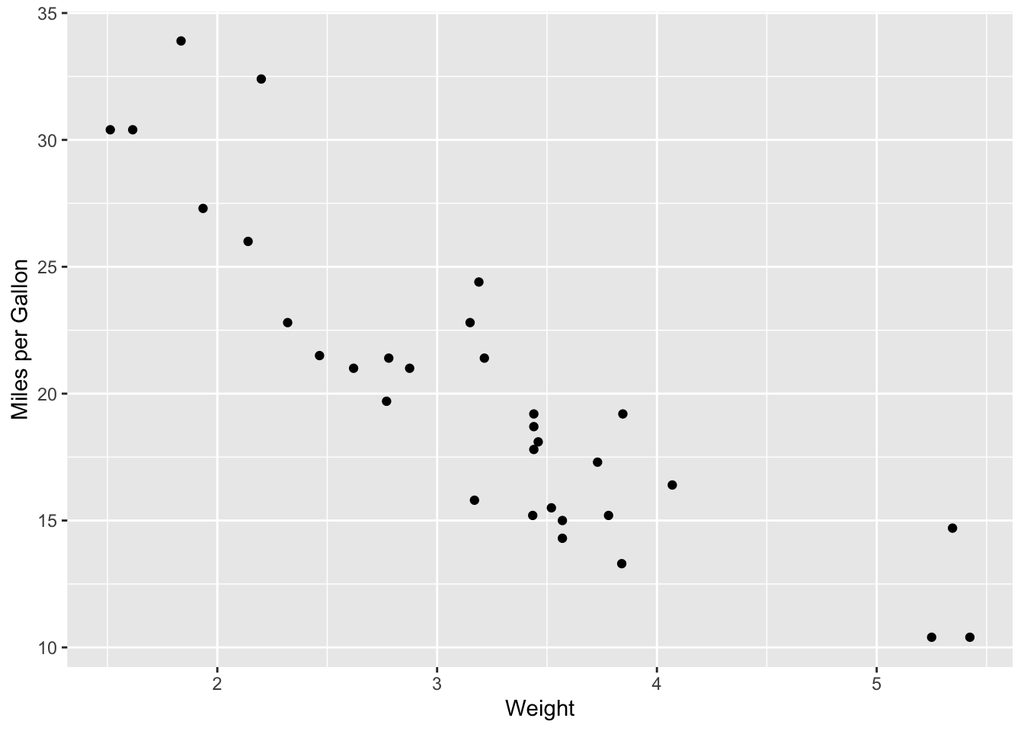

```r
ggplot(mtcars, aes(x = wt, y = mpg))  +
  geom_point() +
  xlab("Weight") +
  ylab("Miles per Gallon")
```

#### Adding a trend line

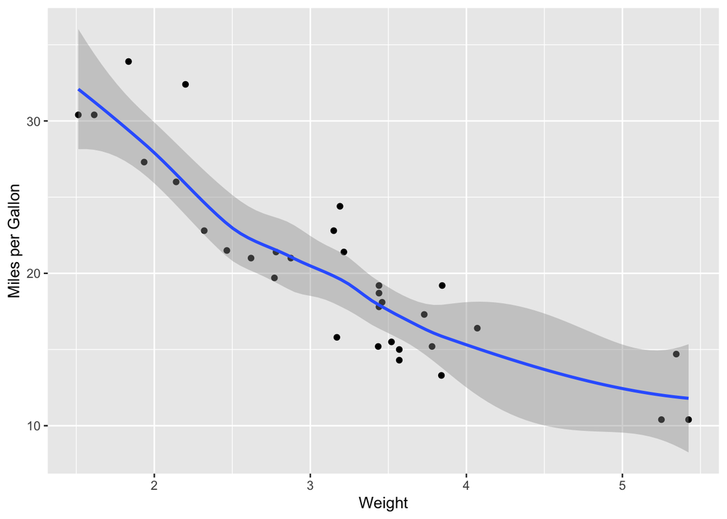

```r
ggplot(mtcars, aes(x = wt, y = mpg))  +
  geom_point() +
  geom_smooth() +
  xlab("Weight") +
  ylab("Miles per Gallon")
```

Recall, in Base R, the scatter plot is,

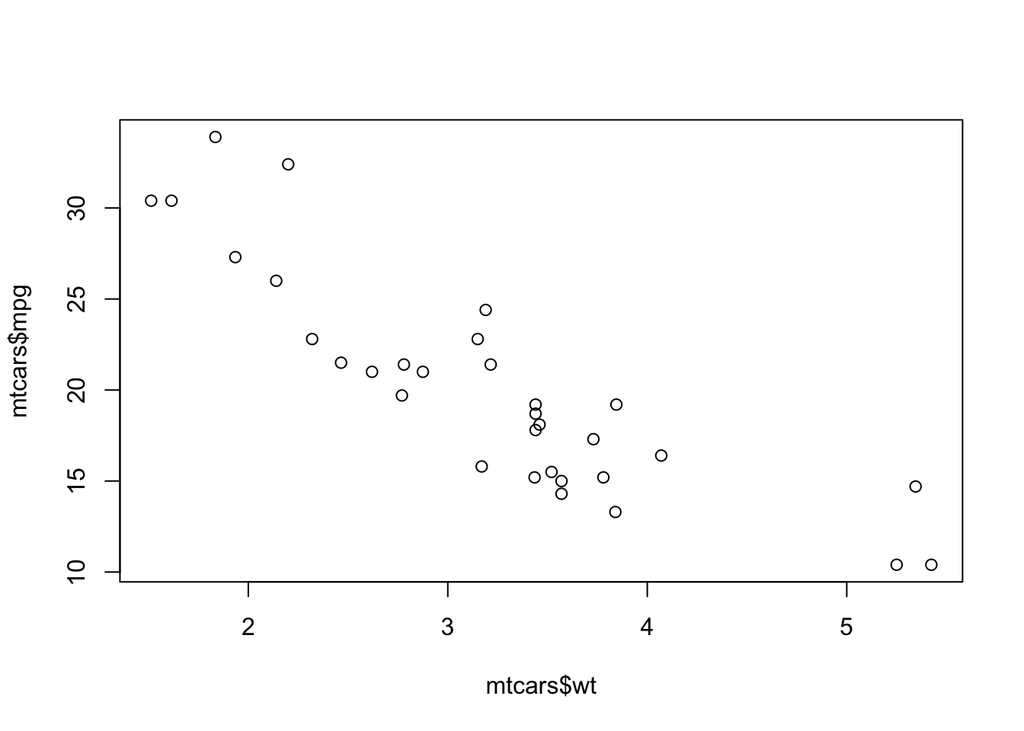

```r
plot(mtcars$wt, mtcars$mpg)
```

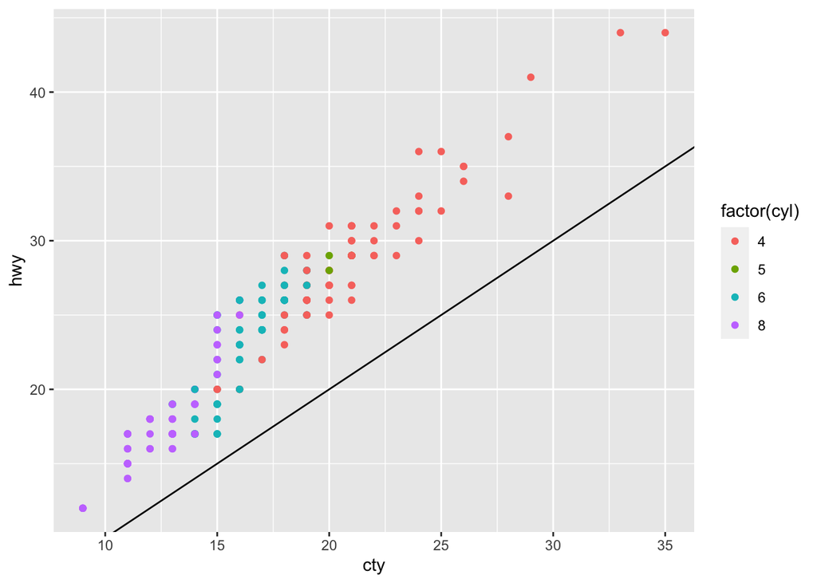

```r
G = ggplot(mpg, aes(cty, hwy, color = factor(cyl))) +
    geom_point() +
  geom_abline()
G
```

## Line Graph

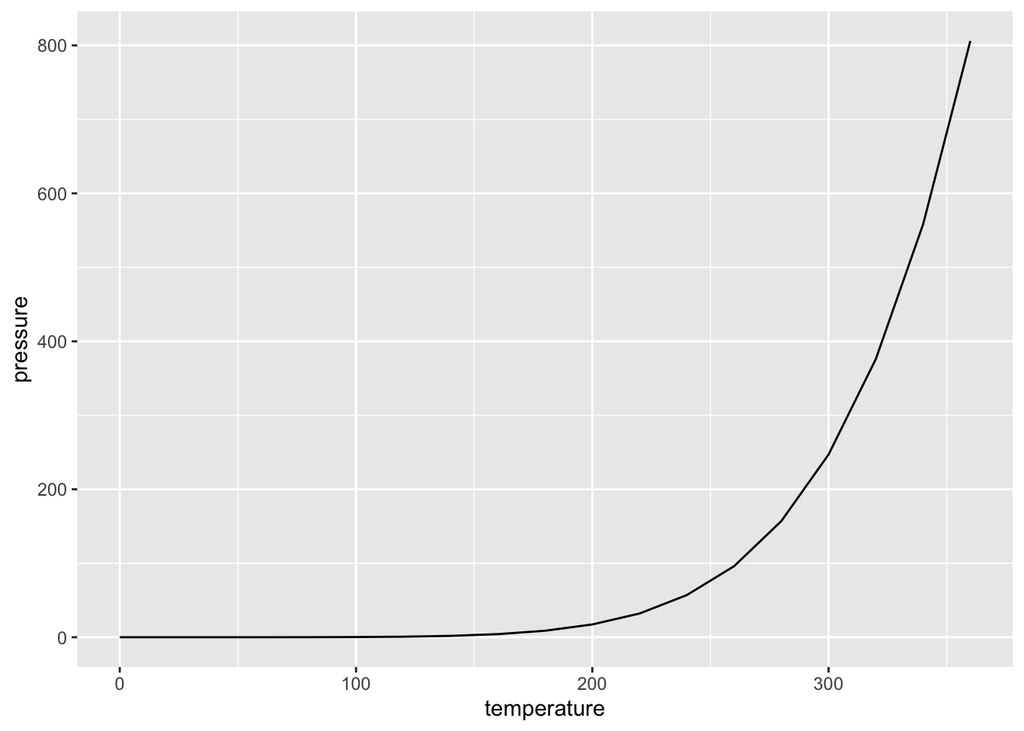

```r
ggplot(pressure, aes(x = temperature, y = pressure)) +
  geom_line()
```

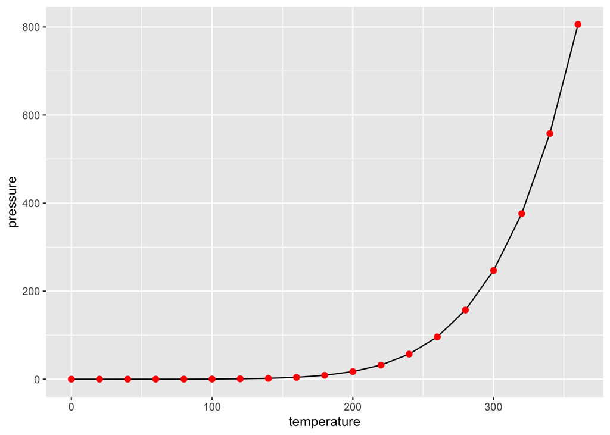

```r
ggplot(pressure, aes(x = temperature, y = pressure)) +
  geom_line() +
  geom_point(size=2, color = "red")
```

In Base R, to make a line graph pass a vector of $x$ values and a vector of $y$ values to the `plot()` function. Use `type = "l"`

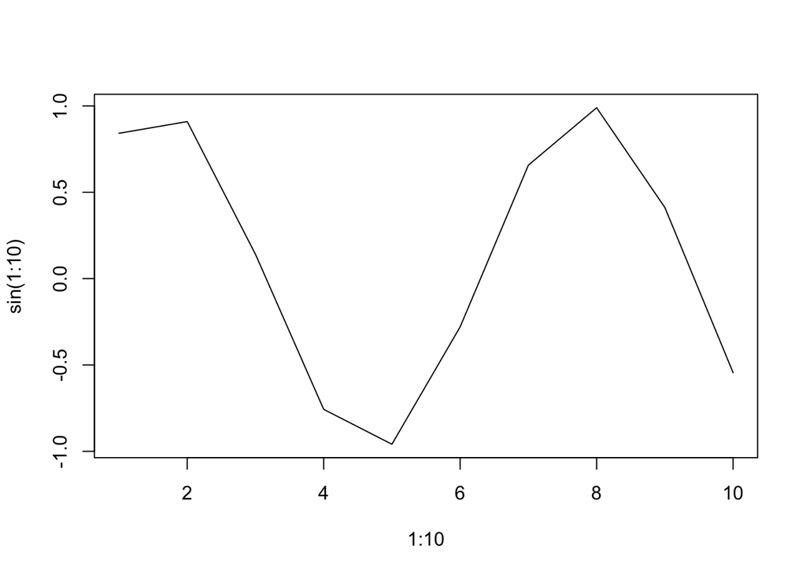

```r
plot(1:10, sin(1:10), type="l")
```

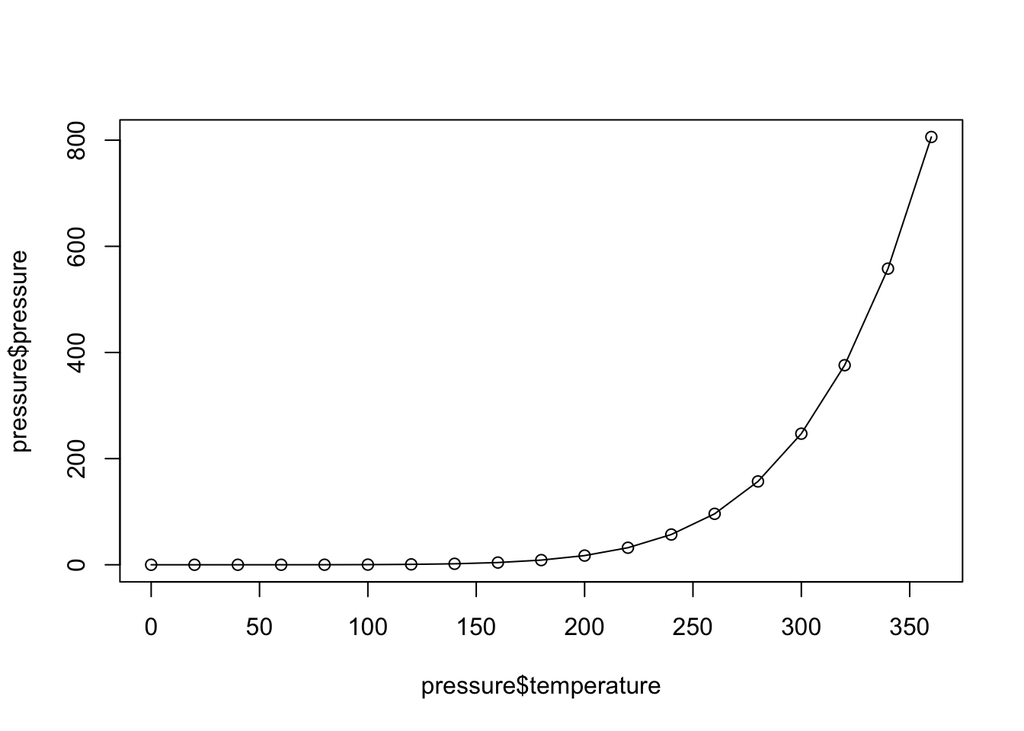

```r
plot(pressure$temperature, pressure$pressure, type='l')   # line
points(pressure$temperature, pressure$pressure)           # points
```

```r
# additional lines with `lines()`
# lines(pressure$temperature, pressure$pressure/2, col = "red")
```

## Bar Graph

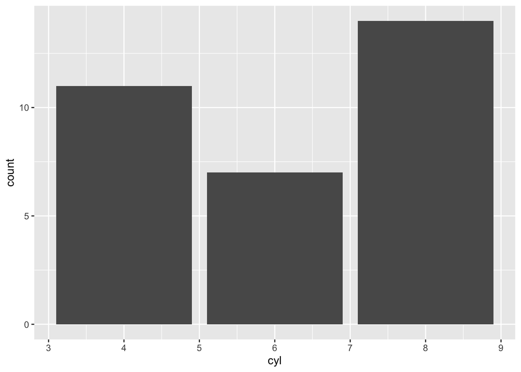

```r
# Bar graph of counts This uses the mtcars data frame, with the "cyl" column for
# x position. The y position is calculated by counting the number of rows for
# each value of cyl.
ggplot(mtcars, aes(x = cyl)) +
  geom_bar()
```

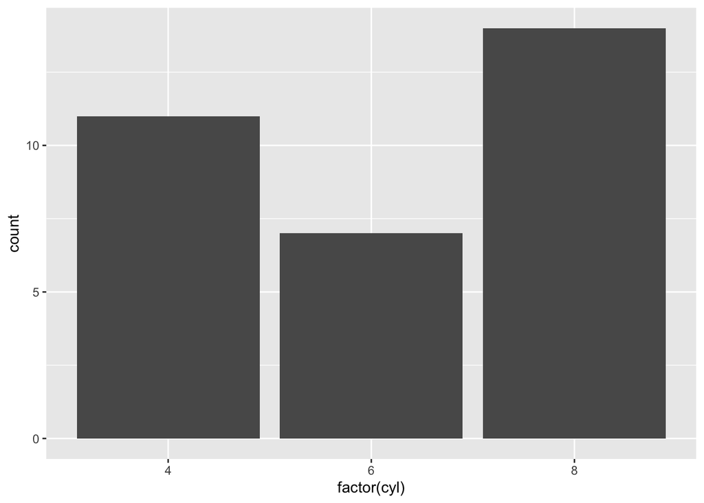

```r
# Bar graph of counts
ggplot(mtcars, aes(x = factor(cyl))) +
  geom_bar()
```

Base R:

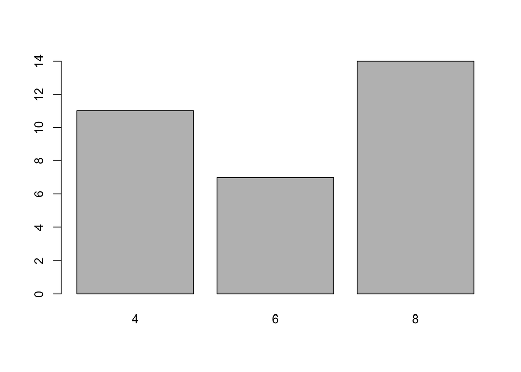

```r
# Generate a table of counts
barplot(table(mtcars$cyl))
```

### Histogram

Univariate numeric data used for frequency counts.

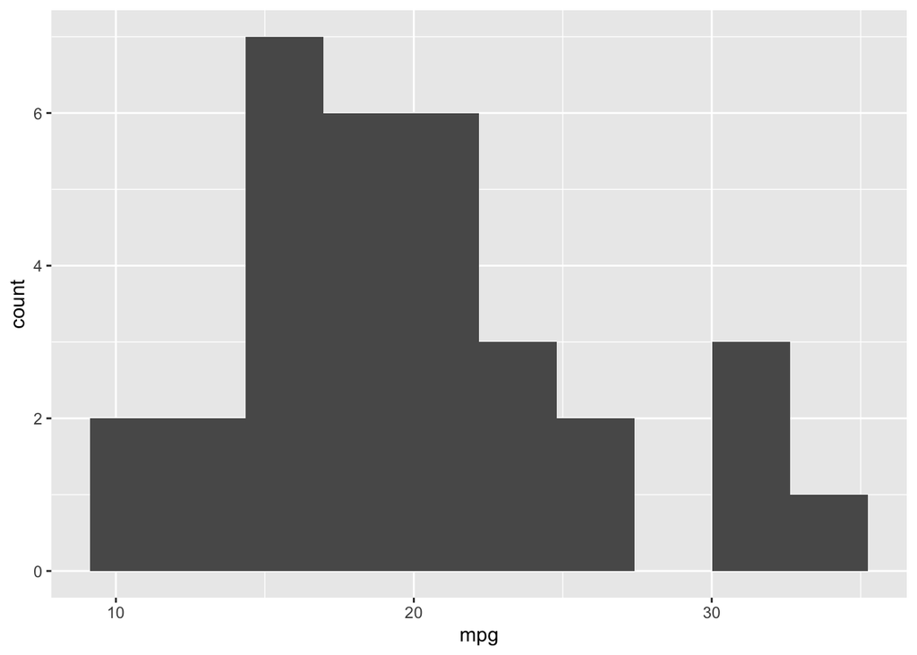

```r
ggplot(mtcars, aes(x = mpg)) +
  geom_histogram(bins = 10)  # see also binwidth = 4, etc.
```

Base R

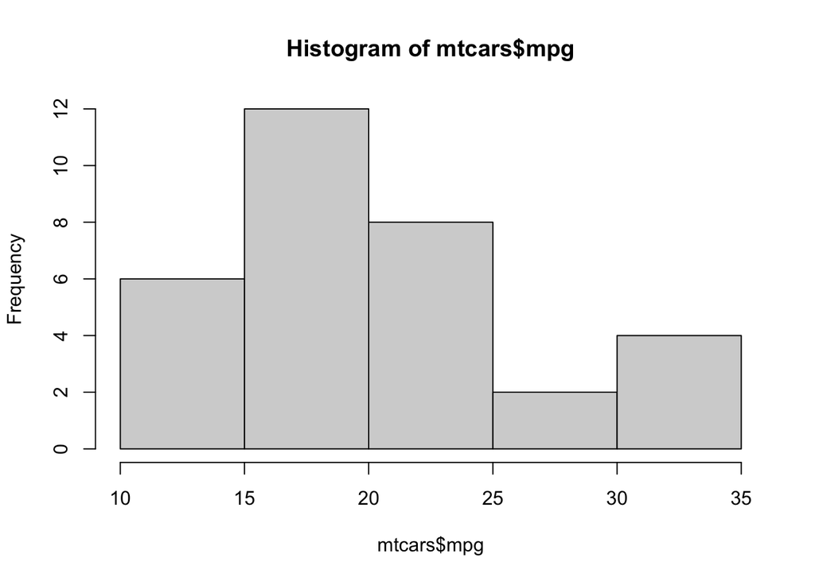

```r
hist(mtcars$mpg)
```

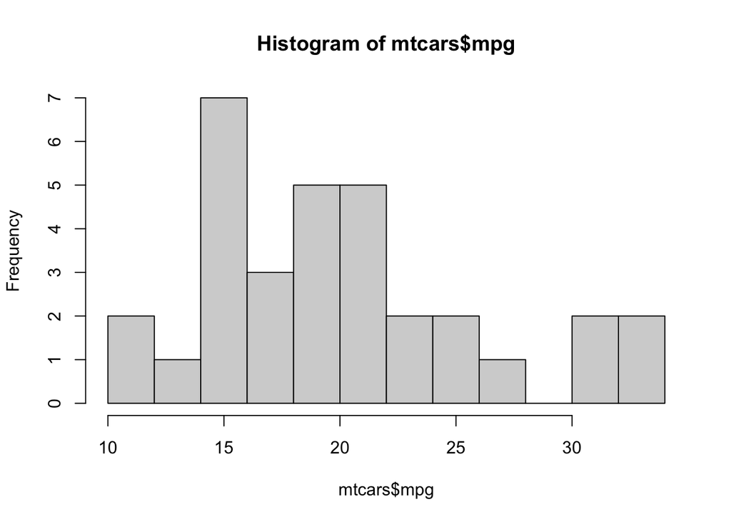

```r
# Specify approximate number of bins with breaks
hist(mtcars$mpg, breaks = 10)
```

## Exercises

1. How would you describe the relationship between cty and hwy? Do you have any concerns about drawing conclusions from that plot?

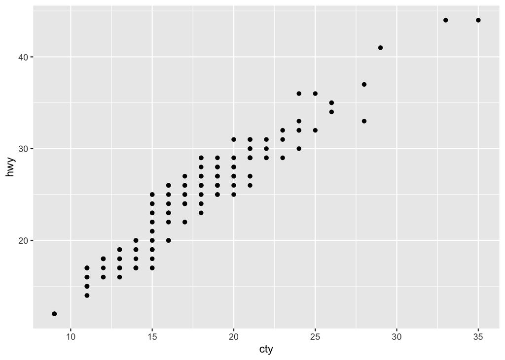

```r
ggplot(mpg, aes(x = cty, y = hwy)) + geom_point()
```

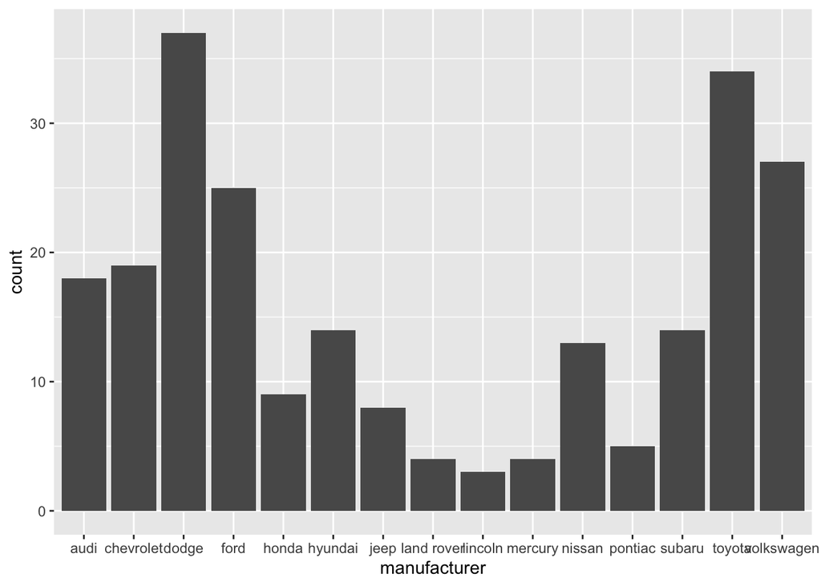

```r
ggplot(mpg, aes(manufacturer)) + geom_bar()
```

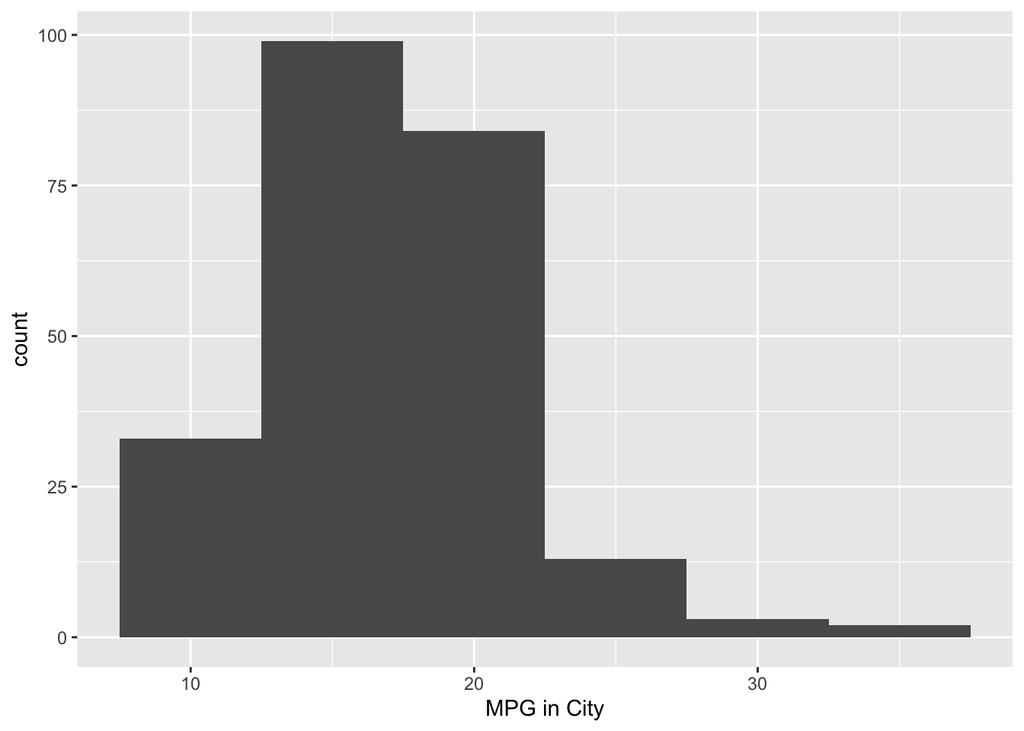

```r
ggplot(mpg, aes(cty)) + geom_histogram(binwidth = 5) + xlab("MPG in City")
```

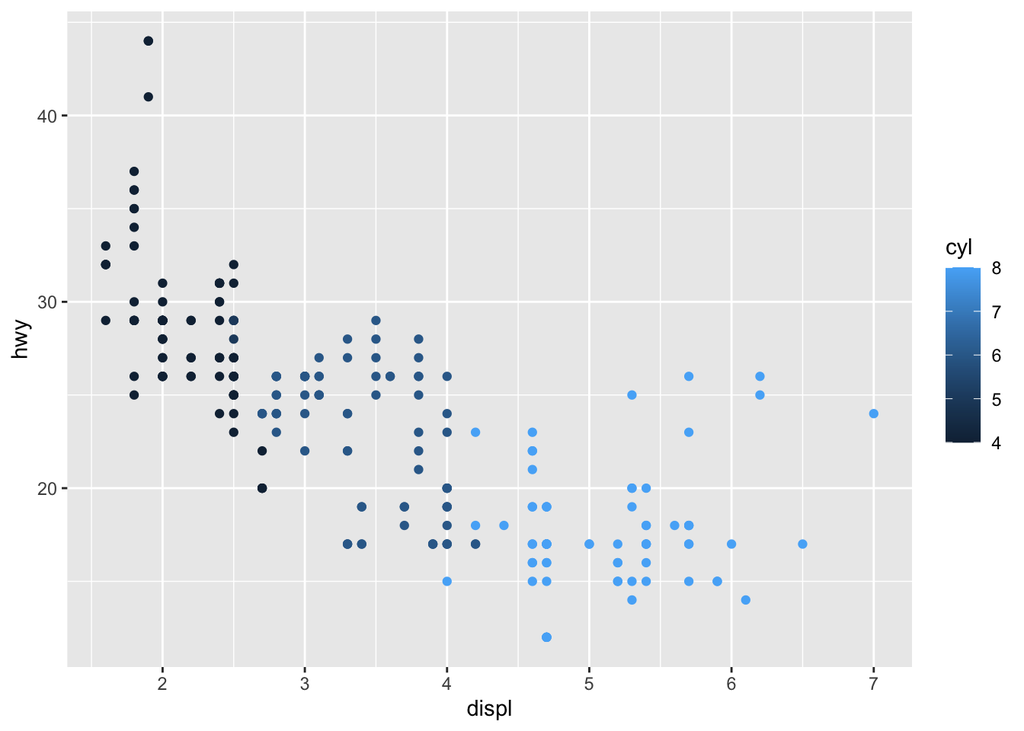

```r
ggplot(mpg, aes(displ, hwy, color = cyl)) + geom_point()
```

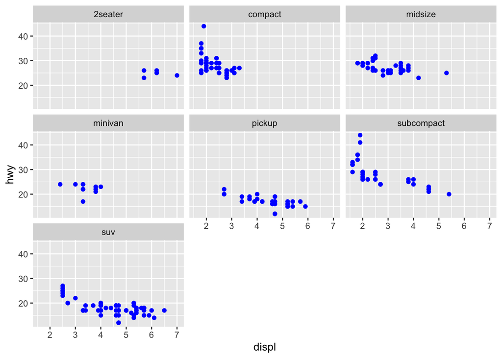

```r
ggplot(mpg, aes(displ, hwy)) +
  geom_point(color="blue") +
  facet_wrap(~class)
```

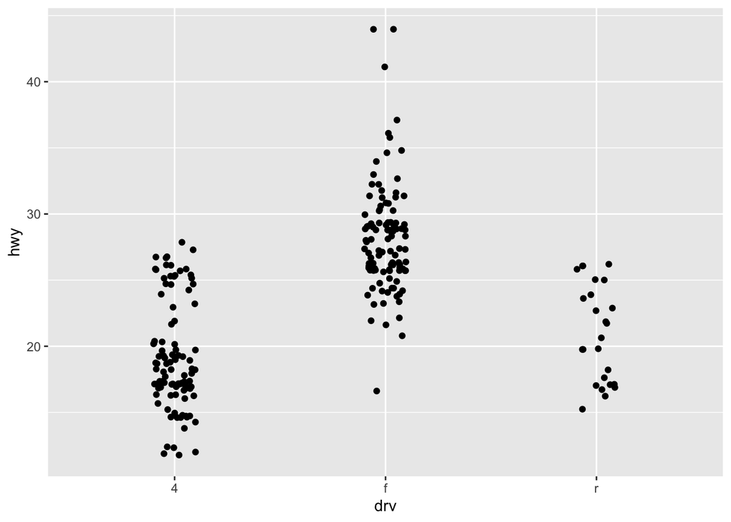

```r
ggplot(mpg, aes(drv, hwy)) + geom_jitter(width=0.1)
```

```r
#ggplot(mpg, aes(drv, hwy)) + geom_boxplot()
#ggplot(mpg, aes(drv, hwy)) + geom_violin()
```

## Frequency Plot

A histogram with a line. Accepts binwidth parameter as argument in `geom_freqpoly()`.

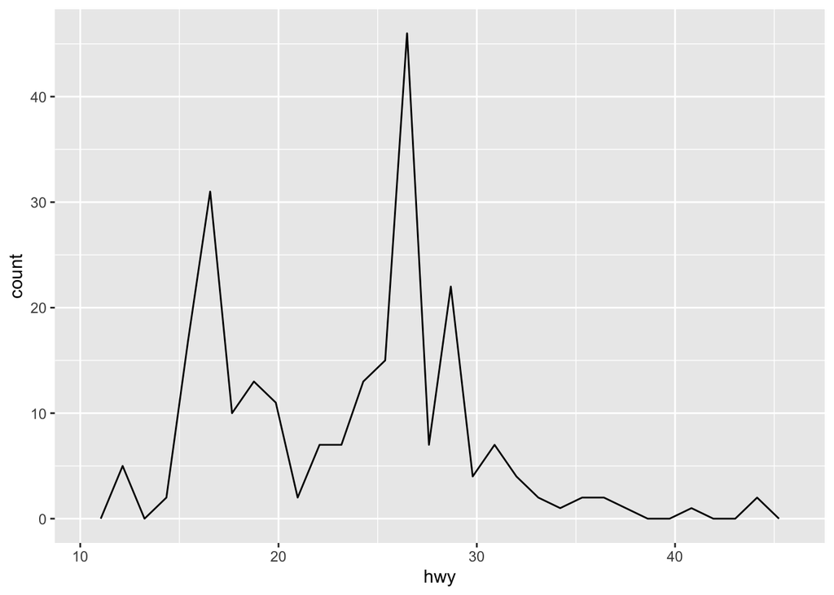

```r
ggplot(mpg, aes(hwy)) + geom_freqpoly()
```

##### Multiple plots

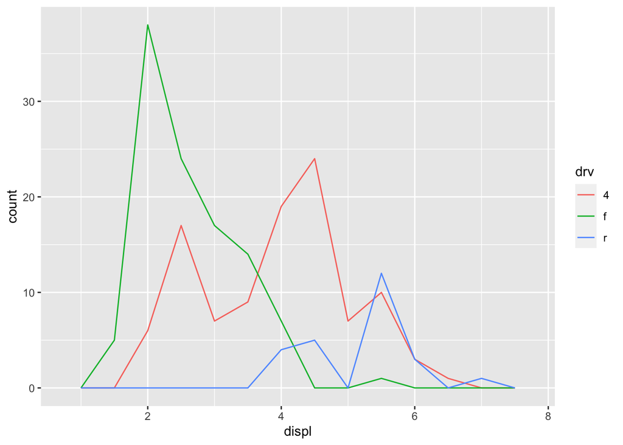

```r
ggplot(mpg, aes(displ, color = drv)) +  geom_freqpoly(binwidth = 0.5)
```

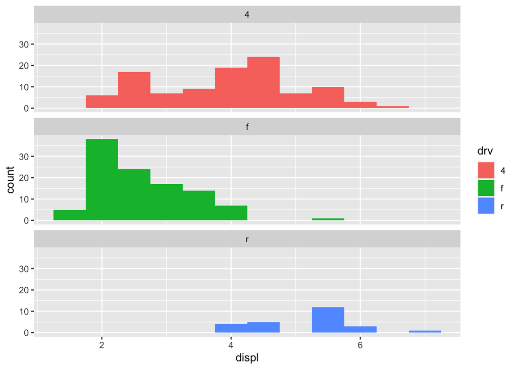

```r
ggplot(mpg, aes(displ, fill = drv)) +
  geom_histogram(binwidth = 0.5) +
  facet_wrap(~drv, ncol = 1)
```

## Boxplots

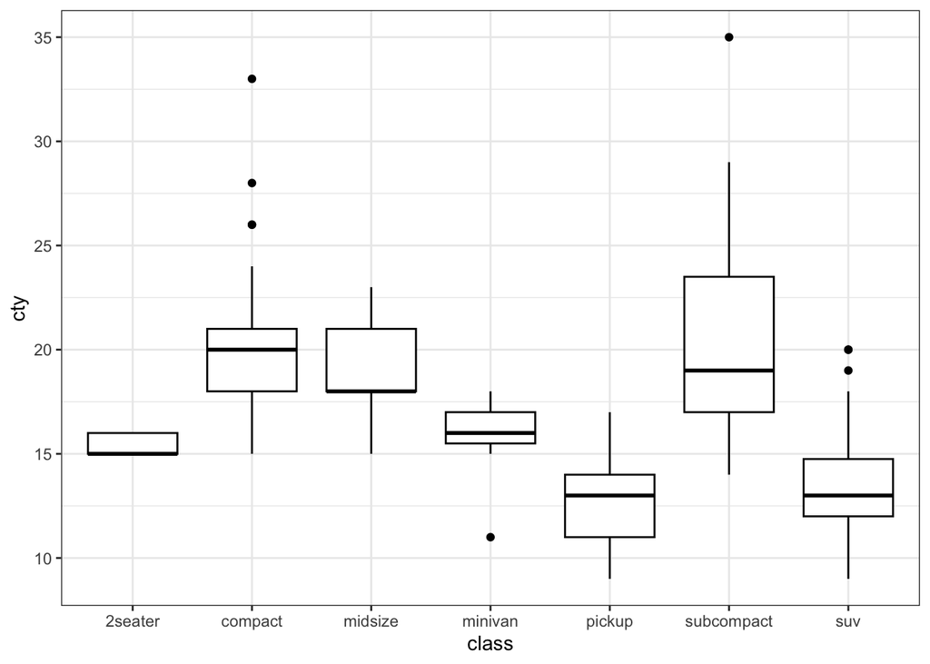

```r
ggplot(mpg, aes(class, cty)) + geom_boxplot(color="black") + theme_bw()
```

Base R

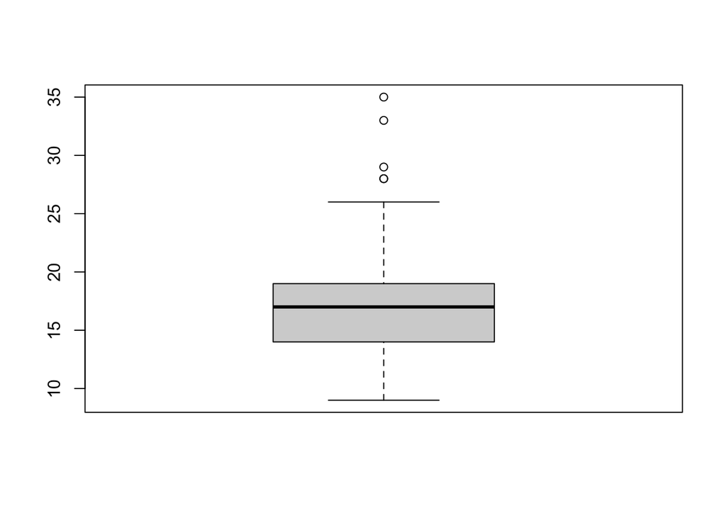

```r
boxplot(mpg$cty)
```

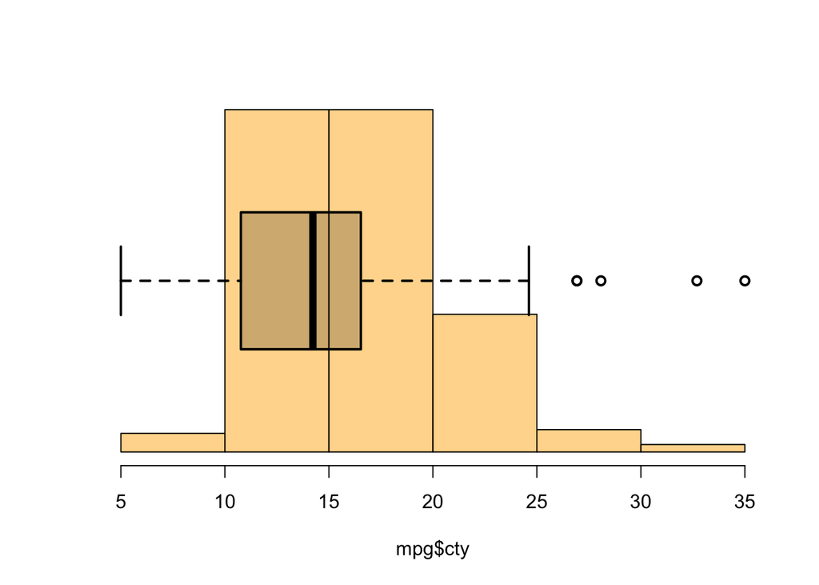

```r
hist(mpg$cty, probability = TRUE, ylab = "", main = "",
     col = rgb(1, .7, 0.1, alpha = 0.5), axes = FALSE)
axis(1) # Adds horizontal axis
par(new = TRUE)
boxplot(mpg$cty, horizontal = TRUE, axes = FALSE,
        lwd = 2, col = rgb(0, 0, 0, alpha = 0.2))
```

### References

[1] Baumer, B. S., Kaplan, D. T., & Horton, N. J. (2017). *Texts in Statistical Science: Modern Data Science with R*. Chapman and Hall/CRC.

```
@book{baumer2017texts,
  title={Texts in Statistical Science: Modern Data Science with R},
  author={Baumer, Benjamin S and Kaplan, Daniel T and Horton, Nicholas J},
  year={2017},
  publisher={Chapman and Hall/CRC}
}
```